# LUW2017 Horseshoe testing

Arnie Seong

17 September 2025

# Linear data (1 run)

basic simulation setting:

- p > n
- sparse truth (4 true covariates, 100 nuisance)
- p = 104, n = 100
- 100 obs generated as basic linear regression $y = X\beta + \epsilon$, with $\epsilon_i \sim N(0,1)$
- Only first 4 covariates in $X$ (out of 104) actually have an effect (rest are nuisance var.s).
- multivariate response also generated (but not used for now)

## Horseshoe model

```r
library(torch)
d_in <- 104
SLHS <- nn_module(
  "SLHS",
  initialize = function() {
    self$fc1 = torch_hs(
      in_features = d_in,
      out_features = 1,
      use_cuda = FALSE,
      tau = 1,
      init_weight = NULL,
      init_bias = NULL,
      init_alpha = 0.9,
      clip_var = NULL
    )
  },

  forward = function(x) {
    x %>%
      self$fc1()
  },

  get_model_kld = function(){
    kld = self$fc1$get_kl()
    return(kld)
  }
)
```

```r
# ## This chunk only runs if params$retrain == TRUE
# ## generate linear data
# n_obs <- 100
# true_coefs = c(-0.5, 1, -2, 4, rep(0, times = 100))
# set.seed(params$seed)
# torch_manual_seed(params$seed)
# slhs_net <- SLHS()
# err_sig <- 1
# lin_simdat <- sim_linear_data(
#   n = n_obs,
#   true_coefs = true_coefs,
#   err_sigma = err_sig
# )
#
# train_epochs <- 200000
#
# convergence_crit <- 1e-7
#
# slhs_net(lin_simdat$x)
# optim_slhs <- optim_adam(slhs_net$parameters)
# loss_diff <- 1
# loss <- torch_zeros(1)
#
# verbose <- TRUE
# epoch <- 1
# while (epoch < train_epochs & abs(loss_diff) > convergence_crit){
#   prev_loss <- loss
#   epoch <- epoch + 1
#
#   y_pred <- slhs_net(lin_simdat$x)
#
#   mse <- nnf_mse_loss(y_pred, lin_simdat$y)
#   kl <- slhs_net$get_model_kld() / lin_simdat$n
#
#   loss <- mse + kl
#   loss_diff <- (loss - prev_loss)$item()
#
#
#   if(epoch %% 1000 == 0 & verbose){
#     cat(
#       "Epoch: ", epoch,
#       "MSE + KL/n = ", mse$item(), " + ", kl$item(),
#       " = ", loss$item(),
#       "\n"
#     )
#     # Eztilde <- slhs_net$fc1$get_Eztilde_i()
#     # Vztilde <- slhs_net$fc1$get_Vztilde_i()
#     # cat("E[ztilde_i]: ", round(as_array(Eztilde), 4), "\n \n")
#     # cat("V[ztilde_i]: ", round(as_array(Vztilde), 4), "\n \n \n")
#     # cat(round(as_array(slnj_net$fc1$z_mu), 4), "\n")
#     w_mu <- slhs_net$fc1$compute_posterior_param()$post_weight_mu
#     cat("E[W|y]: ", round(as_array(w_mu), 2), "\n")
#     dropout_alphas <- slhs_net$fc1$get_dropout_rates()
#     cat("alphas: ", round(as_array(dropout_alphas), 2), "\n \n")
#   }
#
#   # zero out previous gradients
#   optim_slhs$zero_grad()
#   # backprop
#   loss$backward()
#   # update weights
#   optim_slhs$step()
# }
#
#
#
# contents <- list(
#   "n_obs" = n_obs,
#   "true_coefs" = true_coefs,
#   "seed" = params$seed,
#   "err_sig" = err_sig
# )
#
# save(contents, file = here::here("Rcode", "results", "hshoe_linfunc.Rdata"))
# torch_save(slhs_net, path = here::here("Rcode", "results", "hshoe_linfunc.pt"))
```

```r
load(file = here::here("Rcode", "results", "hshoe_linfunc.Rdata"))
slhs_net <- torch_load(path = here::here("Rcode", "results", "hshoe_linfunc.pt"))

# recreate lin_simdat from `contents` list
set.seed(contents$params$seed)
err_sig <- contents$err_sig
n_obs <- contents$n_obs
true_coefs <- contents$true_coefs

lin_simdat <- sim_linear_data(
  n = n_obs,
  true_coefs = true_coefs,
  err_sigma = err_sig
)

# posterior weight parameters
post_wmu <- slhs_net$fc1$compute_posterior_param()$post_weight_mu
post_wvar <- slhs_net$fc1$compute_posterior_param()$post_weight_var

post_wmu_mat <- matrix(as_array(post_wmu))
post_wvar_mat <- matrix(as_array(post_wvar))

mykable(
  matrix(round(post_wmu_mat, 3), nrow = 8, byrow = TRUE),
  cap = "posterior mean weights (in 8 rows)"
)
```

posterior mean weights (in 8 rows)

| -0.364 | 1.058 | -1.904 | 3.946 | 0.000 | -0.002 | -0.003 | -0.004 | -0.015 | 0.000 | 0.004 | -0.006 | 0.002 |
| --- | --- | --- | --- | --- | --- | --- | --- | --- | --- | --- | --- | --- |
| 0.004 | -0.007 | -0.001 | 0.000 | 0.000 | -0.003 | -0.015 | 0.009 | -0.001 | -0.004 | 0.091 | 0.002 | -0.003 |
| 0.007 | 0.007 | 0.007 | 0.004 | 0.001 | 0.003 | 0.000 | 0.006 | 0.010 | -0.002 | -0.035 | 0.001 | 0.007 |
| 0.005 | 0.010 | 0.005 | 0.003 | 0.006 | -0.005 | -0.003 | 0.025 | -0.002 | -0.080 | 0.010 | -0.004 | 0.012 |
| 0.002 | -0.002 | 0.002 | 0.010 | 0.004 | 0.003 | -0.005 | -0.001 | 0.008 | -0.005 | 0.013 | -0.015 | 0.005 |
| 0.006 | 0.005 | 0.006 | 0.026 | -0.021 | -0.036 | 0.003 | -0.007 | -0.002 | 0.005 | 0.001 | -0.008 | 0.011 |
| 0.064 | 0.015 | 0.001 | -0.064 | -0.003 | 0.003 | 0.003 | 0.005 | -0.049 | 0.006 | -0.003 | 0.015 | -0.004 |
| 0.007 | -0.006 | 0.008 | -0.008 | -0.011 | 0.005 | -0.001 | -0.012 | -0.004 | -0.010 | -0.004 | -0.014 | -0.003 |

```r
mykable(
  matrix(true_coefs, nrow = 8, byrow = TRUE),
  cap = "true regression coefficients (in 8 rows)"
)
```

true regression coefficients (in 8 rows)

| -0.5 | 1 | -2 | 4 | 0 | 0 | 0 | 0 | 0 | 0 | 0 | 0 | 0 |
| --- | --- | --- | --- | --- | --- | --- | --- | --- | --- | --- | --- | --- |
| 0.0 | 0 | 0 | 0 | 0 | 0 | 0 | 0 | 0 | 0 | 0 | 0 | 0 |
| 0.0 | 0 | 0 | 0 | 0 | 0 | 0 | 0 | 0 | 0 | 0 | 0 | 0 |
| 0.0 | 0 | 0 | 0 | 0 | 0 | 0 | 0 | 0 | 0 | 0 | 0 | 0 |
| 0.0 | 0 | 0 | 0 | 0 | 0 | 0 | 0 | 0 | 0 | 0 | 0 | 0 |
| 0.0 | 0 | 0 | 0 | 0 | 0 | 0 | 0 | 0 | 0 | 0 | 0 | 0 |
| 0.0 | 0 | 0 | 0 | 0 | 0 | 0 | 0 | 0 | 0 | 0 | 0 | 0 |
| 0.0 | 0 | 0 | 0 | 0 | 0 | 0 | 0 | 0 | 0 | 0 | 0 | 0 |

```r
post_params_waldish <- as_array(post_wmu^2 / post_wvar)
post_params_inclusion <- post_params_waldish > 2

mykable(
  matrix(round(post_params_waldish, 3), nrow = 8, byrow = TRUE),
  cap = "Wald-like posterior weights' (mean^2 / variance)"
)
```

Wald-like posterior weights’ (mean^2 / variance)

| 42.420 | 228.726 | 692.952 | 2295.569 | 0.001 | 0.013 | 0.029 | 0.050 | 0.509 | 0.001 | 0.046 | 0.118 | 0.013 |
| --- | --- | --- | --- | --- | --- | --- | --- | --- | --- | --- | --- | --- |
| 0.069 | 0.184 | 0.002 | 0.001 | 0.000 | 0.027 | 0.570 | 0.241 | 0.007 | 0.052 | 4.708 | 0.011 | 0.029 |
| 0.164 | 0.149 | 0.136 | 0.056 | 0.003 | 0.025 | 0.001 | 0.127 | 0.265 | 0.014 | 1.573 | 0.009 | 0.150 |
| 0.088 | 0.234 | 0.067 | 0.029 | 0.135 | 0.096 | 0.029 | 0.972 | 0.019 | 4.188 | 0.307 | 0.059 | 0.402 |
| 0.021 | 0.021 | 0.016 | 0.262 | 0.059 | 0.024 | 0.092 | 0.009 | 0.194 | 0.102 | 0.431 | 0.562 | 0.078 |
| 0.109 | 0.090 | 0.097 | 1.093 | 0.885 | 1.636 | 0.034 | 0.162 | 0.008 | 0.072 | 0.003 | 0.157 | 0.351 |
| 3.221 | 0.495 | 0.005 | 3.507 | 0.032 | 0.028 | 0.043 | 0.083 | 2.447 | 0.113 | 0.029 | 0.527 | 0.044 |
| 0.152 | 0.108 | 0.172 | 0.191 | 0.340 | 0.076 | 0.004 | 0.436 | 0.061 | 0.294 | 0.055 | 0.500 | 0.043 |

```r
mykable(
  matrix(post_params_inclusion, nrow = 8, byrow = TRUE),
  cap = "inclusion based on posterior weights' (mean^2 / variance) > 2"
)
```

inclusion based on posterior weights’ (mean^2 / variance) > 2

| TRUE | TRUE | TRUE | TRUE | FALSE | FALSE | FALSE | FALSE | FALSE | FALSE | FALSE | FALSE | FALSE |
| --- | --- | --- | --- | --- | --- | --- | --- | --- | --- | --- | --- | --- |
| FALSE | FALSE | FALSE | FALSE | FALSE | FALSE | FALSE | FALSE | FALSE | FALSE | TRUE | FALSE | FALSE |
| FALSE | FALSE | FALSE | FALSE | FALSE | FALSE | FALSE | FALSE | FALSE | FALSE | FALSE | FALSE | FALSE |
| FALSE | FALSE | FALSE | FALSE | FALSE | FALSE | FALSE | FALSE | FALSE | TRUE | FALSE | FALSE | FALSE |
| FALSE | FALSE | FALSE | FALSE | FALSE | FALSE | FALSE | FALSE | FALSE | FALSE | FALSE | FALSE | FALSE |
| FALSE | FALSE | FALSE | FALSE | FALSE | FALSE | FALSE | FALSE | FALSE | FALSE | FALSE | FALSE | FALSE |
| TRUE | FALSE | FALSE | TRUE | FALSE | FALSE | FALSE | FALSE | TRUE | FALSE | FALSE | FALSE | FALSE |
| FALSE | FALSE | FALSE | FALSE | FALSE | FALSE | FALSE | FALSE | FALSE | FALSE | FALSE | FALSE | FALSE |

- posterior weights look good

### dropout rate:

Under the variational distribution,

$$\begin{aligned}
\tilde{z_i}
&= \sqrt{ \tilde{\alpha_i} \tilde{\beta_i} }
\\
\tilde{\beta_i}
& \sim Log-Normal \left( \mu_{\tilde{\beta_i}},
\sigma^2_\tilde{{\beta_i}} \right)
\\
\tilde{\alpha}
& \sim Log-Normal \left( \mu_{\tilde{\alpha}},
\sigma^2_{\tilde{\alpha}} \right)
\\
\end{aligned}$$

If $Y \sim N(\mu_y, \sigma^2_Y)$, then $X = \e^Y \sim Log-Normal(\mu_Y, \sigma^2_Y)$, and the mean and variance of the log-normal-distributed RV $X$ are given by:  
- $E[X] = \exp \left\{ {\mu + \frac{\sigma^2}{2}} \right\}$  
- $Var[X] = \left( \exp{{\sigma^2_Y}} - 1 \right) \exp \left\{2 \mu_Y + \sigma^2_Y \right\}$

Then, for the variational dropout rate, we use the variational parameters of the local shrinkage parameter $\tilde z$, where

$$\tilde z = \sqrt{\tilde{\alpha}
\tilde{\beta}} \sim Log-Normal \left( \dfrac{1}{2} (\mu_{\tilde{\alpha}}
+ \mu_{\tilde{\beta}}), \dfrac{1}{4} (\sigma^2_{\tilde{\alpha}} +
\sigma^2_{\tilde{\beta}}) \right)$$
Then, for the local dropout rate $\alpha_i$, we get:

$$\begin{aligned}
\alpha & =
\dfrac{Var[\tilde{z}]} { \left( E[\tilde{z}] \right)^2 }\\
& =
\dfrac{
\left( exp\{\sigma^2_{\tilde{z}}\} - 1 \right)
\exp \left\{2 \mu_{\tilde{z}} + \sigma^2_{\tilde{z}} \right\}
}{
\left(\exp \left\{ {\mu + \frac{\sigma^2}{2}} \right\} \right)^2
}
\\
& =
\dfrac{
\left( exp\{\sigma^2_{\tilde{z}}\} - 1 \right)
\exp \left\{2 \mu_{\tilde{z}} + \sigma^2_{\tilde{z}} \right\}
}{
\exp \left\{ 2 \mu_{\tilde{z}} + \sigma^2_{\tilde{z}} \right\}
}
\\
& = exp\{\sigma^2_{\tilde{z}}\} - 1
\\
& =
exp \left\{
\dfrac{1}{4} \left( \sigma^2_{\tilde{\alpha}} +
\sigma^2_{\tilde{\beta}} \right) \right \} - 1
\end{aligned}$$

Interestingly, the local shrinkage parameter controls the variational dropout rate only via its variance, which is a nice result since the *model* distribution $p(\tilde{z})$ is half-Cauchy.

Setting the inclusion threshold *ad hoc* to requiring a dropout rate < 0.05 for inclusion, we get a binary error rate of:

```r
# alphas <- log_dropout(hslayer = slhs_net$fc1)
# slhs_net$fc1$get_log_dropout_rates()

alphas <- as_array(slhs_net$fc1$get_dropout_rates())
hskeep_05 <- alphas < .05
hskeep_50 <- alphas < .5

cat("binary error as percentages (sums to 1): \n")
binary_err(est = hskeep_05, tru = true_coefs != 0)

cat("binary error rates (FP + TN = 1, FN + TP = 1): \n")
binary_err_rate(est = hskeep_05, tru = true_coefs != 0)
```

```
## binary error as percentages (sums to 1):
##         FP         TP         FN         TN
## 0.00000000 0.03846154 0.00000000 0.96153846
## binary error rates (FP + TN = 1, FN + TP = 1):
## FP TP FN TN
##  0  1  0  1
```

without any evaluative training regimes besides the number of epochs.

If we were to use the median model (dropout rate < 50% required for inclusion):

```r
cat("MEDIAN MODEL binary error rates (FP + TN = 1, FN + TP = 1): \n")
```

```
## MEDIAN MODEL binary error rates (FP + TN = 1, FN + TP = 1):
```

```r
binary_err_rate(est = hskeep_50, tru = true_coefs != 0)
```

```
##   FP   TP   FN   TN
## 0.01 1.00 0.00 0.99
```

## lm fit

```r
calc_lm_stats <- function(lm_fit, true_coefs, alpha = 0.05){
  beta_hat <- summary(lm_fit)$coef[-1, 1]
  binary_err <- binary_err_rate(
    est = summary(lm_fit)$coef[-1, 4] < alpha,
    tru = true_coefs != 0)
  fit_mse <- mean(lm_fit$residuals^2)
  coef_mse <- mean((beta_hat - true_coefs)^2)
  list(
      "binary_err" = binary_err,
      "fit_mse" = fit_mse,
      "coef_mse" = coef_mse
    )
}

get_lm_stats <- function(simdat, include = NULL, alpha = 0.05){
  lm_df <- data.frame(
    "y" = as_array(simdat$y),
    "x" = as_array(simdat$x)
  )
  if (simdat$d_in > simdat$n){
    last_cov_ind <- ceiling(simdat$n/2)
    # ensure that "include" variables are included
    if (!is.null(include) | length(include) > simdat$d_true){
      add_inds <- include[include %notin% 1:last_cov_ind]
      available_cols <- setdiff((simdat$d_true + 1):last_cov_ind, include)
      lm_df[, (available_cols[1:length(add_inds)])] <- lm_df[, add_inds + 1]
    }
  lm_df <- lm_df[, 1:(last_cov_ind+1)]

  }

  lm_fit <- lm(y ~ ., lm_df)
  if (length(simdat$true_coefs) >= n_obs){
    warning("p >= n; (p - n) + floor(n/2) spurious covariates eliminated to accomodate lm")
    calc_lm_stats(
      lm_fit = lm_fit,
      true_coefs = simdat$true_coefs[1:ceiling(simdat$n/2)],
      alpha = alpha
    )
  } else {
    calc_lm_stats(lm_fit = lm_fit, true_coefs = simdat$true_coefs, alpha = alpha)
  }
}

get_lm_stats(simdat = lin_simdat, include = which(hskeep_50))
```

```
## $binary_err
##         FP         TP         FN         TN
## 0.02173913 0.25000000 0.75000000 0.97826087
##
## $fit_mse
## [1] 7.97291
##
## $coef_mse
## [1] 0.6790945
```

- note that these results are after giving `lm()` quite a large advantage (keeping only half of the nuisance variables)

# Functional Data setting

## checking data generation

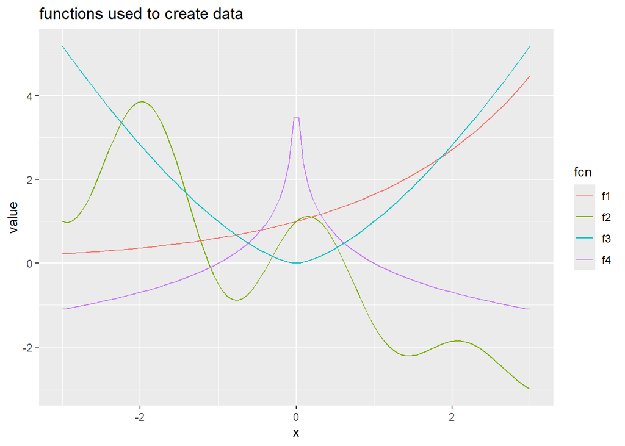

```r
fcn1 <- function(x) exp(x/2)
fcn2 <- function(x) cos(pi*x) + sin(pi/1.2*x) - x
fcn3 <- function(x) abs(x)^(1.5)
# fcn4 <- function(x) -x^2 / 2 -3
fcn4 <- function(x) - log(abs(x))
flist = list(fcn1, fcn2, fcn3, fcn4)

xshow <- seq(-3, 3, length.out = 100)
yshow <- sapply(flist, function(fcn) fcn(xshow))
df <- data.frame(
  "f1" = yshow[, 1],
  "f2" = yshow[, 2],
  "f3" = yshow[, 3],
  "f4" = yshow[, 4],
  "x"  = xshow
)
df %>%
  pivot_longer(cols = -x, names_to = "fcn") %>%
  ggplot(aes(y = value, x = x, color = fcn)) +
  geom_line() +
  labs(title = "functions used to create data")
```

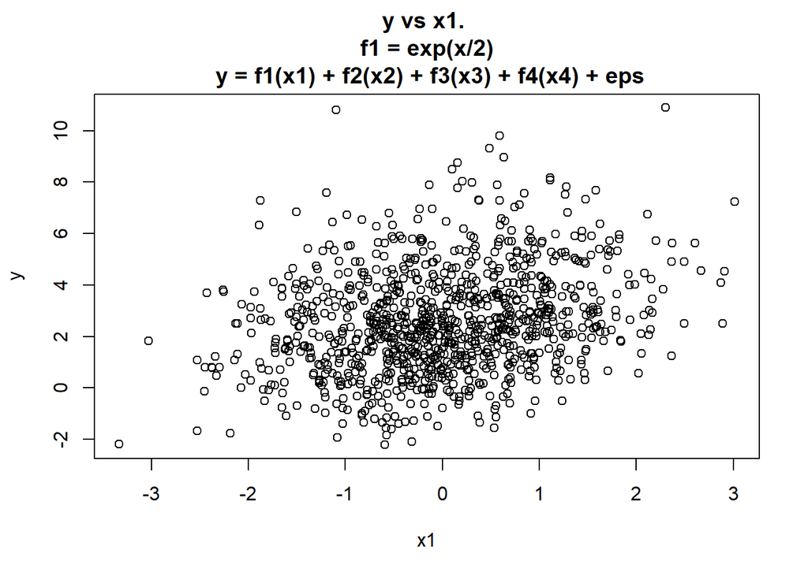

```r
x <- torch_randn(500, d_in)
  y <- rep(0, 500)
  for(j in 1:length(flist)){
    y <- y + flist[[j]](x[,j])
  }

# checking
td <- sim_func_data(flist = flist, err_sigma = 0)

y <- as_array(td$y)
x1 <- as_array(td$x[,1])
x2 <- as_array(td$x[, 2])
x3 <- as_array(td$x[, 3])
x4 <- as_array(td$x[, 4])

plot(x1, y, main = "y vs x1. \n f1 = exp(x/2) \n y = f1(x1) + f2(x2) + f3(x3) + f4(x4) + eps")
```

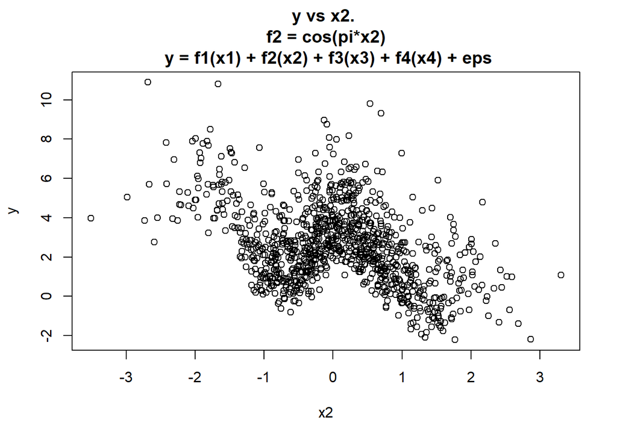

```r
plot(x2, y, main = "y vs x2. \n f2 = cos(pi*x2) \n y = f1(x1) + f2(x2) + f3(x3) + f4(x4) + eps")
```

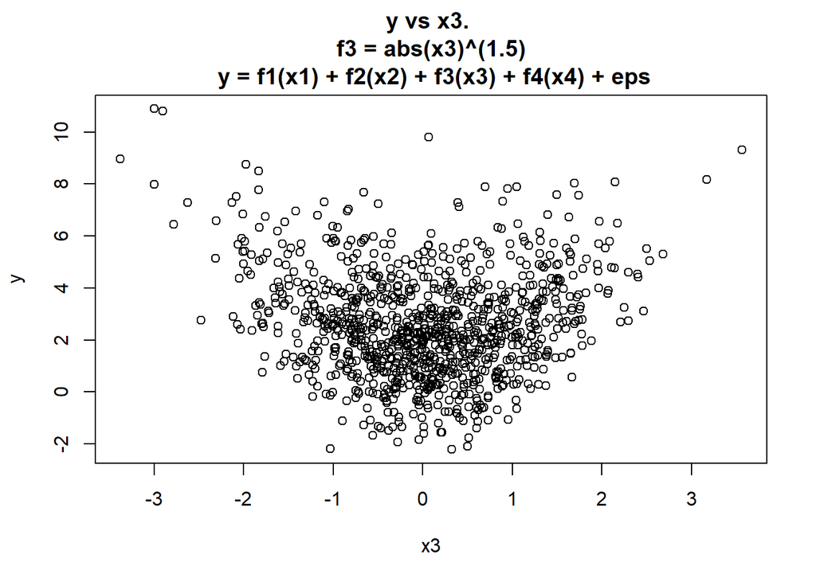

```r
plot(x3, y, main = "y vs x3. \n f3 = abs(x3)^(1.5) \n y = f1(x1) + f2(x2) + f3(x3) + f4(x4) + eps")
```

[figure not shown]

```r
plot(x4, y, main = "y vs x4. \n f4 = cos(pi*x4) + sin(pi/1.2*x4) - x4 \n y = f1(x1) + f2(x2) + f3(x3) + f4(x4) + eps")
```

## gen data, define NNet

Generate data with 4 covariates that are non-linearly related to the outcome (as above), and 100 nuisance covariates. See if we can pick them out.

```r
n_obs <- 10000
d_in <- 104
set.seed(params$seed)
torch_manual_seed(params$seed)
fdat <- sim_func_data(
  n = n_obs,
  d_in = d_in,
  flist = flist,
  err_sigma = 1)

# fdat <- sim_linear_data(
#   n_obs = n_obs,
#   d_in = d_in,
#   d_true = 4,
#   err_sigma = 1,
#   true_coefs = true_coefs[1:d_in]
# )



d_hidden1 <- 16
d_hidden2 <- 8
d_out <- 1

MLHS <- nn_module(
  "Multi-layer Horseshoe",

  initialize = function() {

    self$fc1 = torch_hs(
      in_features = d_in,
      out_features = d_hidden1,
      use_cuda = FALSE,
      tau = 1,
      init_weight = NULL,
      init_bias = NULL,
      init_alpha = 0.9,
      clip_var = TRUE
    )

    self$fc2 = torch_hs(
      in_features = d_hidden1,
      out_features = d_hidden2,
      use_cuda = FALSE,
      tau = 1,
      init_weight = NULL,
      init_bias = NULL,
      init_alpha = 0.9,
      clip_var = TRUE
    )

    self$fc3 = torch_hs(
      in_features = d_hidden2,
      out_features = d_out,
      use_cuda = FALSE,
      tau = 1,
      init_weight = NULL,
      init_bias = NULL,
      init_alpha = 0.9,
      clip_var = TRUE
    )

  },

  forward = function(x) {
    x %>%
      self$fc1() %>%
      nnf_relu() %>%
      self$fc2() %>%
      nnf_relu() %>%
      self$fc3()
  },



  get_model_kld = function(){
    kl1 = self$fc1$get_kl()
    kl2 = self$fc2$get_kl()
    kl3 = self$fc3$get_kl()
    kld = kl1 + kl2 + kl3
    return(kld)
  }
)
```

## train

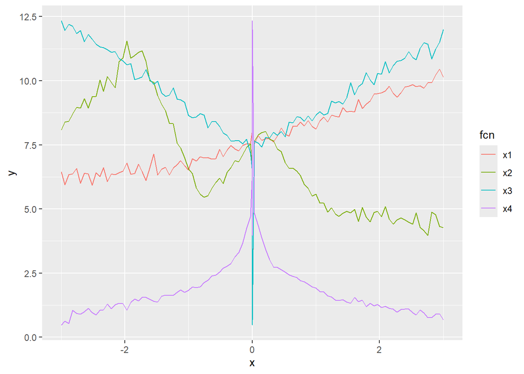

```r
fcn_model <- MLHS()
x <- fdat$x
y <- fdat$y



# setup plotting while training
curvmat <- cbind(
  c(xshow, rep(0, 100*3)),
  c(rep(0, 100), xshow, rep(0, 100*2)),
  c(rep(0, 100*2), xshow, rep(0, 100)),
  c(rep(0, 100*3), xshow)
)
mat0 <- matrix(0, nrow = 400, ncol = 100)
x_plot <- torch_tensor(cbind(curvmat, mat0))

y_plot <- fcn_model(x_plot)  # need to add deterministic argument
plotmat <- cbind(as_array(y_plot), curvmat)
colnames(plotmat) <- c("y", "x1", "x2", "x3", "x4")
plotdf <- as.data.frame(plotmat)
#
#
#
#
#
# # training params / results
# optim <- optim_adam(fcn_model$parameters)
#
# train_epochs <- 500000
# loss_mat <- array(data = NA, dim = c(train_epochs/100, 4))
# colnames(loss_mat) <- c("epoch", "mse", "kl", "loss")
#
# for (epoch in 1:train_epochs){
#
#   y_pred <- fcn_model(x)
#   mse <- nnf_mse_loss(y_pred, y)
#   kl <- fcn_model$get_model_kld() / fdat$n
#   loss <- mse + kl
#
#   if(epoch %% 10000 == 0){
#     cat(
#       "Epoch: ", epoch,
#       "MSE + KL/n = ", mse$item(), " + ", kl$item(),
#       " = ", loss$item(),
#       "\n"
#     )
#     dropout_alphas <- fcn_model$fc1$get_dropout_rates()
#     cat(round(as_array(dropout_alphas), 4), "\n")
#     loss_mat[epoch/100, ] = c(epoch, mse$item(), kl$item(), loss$item())
#     plotdf$y <- as_array(fcn_model(x_plot))
#     plt <- plotdf %>%
#       gather(key = "fcn", value = "x", -y) %>%
#       ggplot(aes(y = y, x = x, color = fcn)) +
#       geom_line()
#     print(plt)
#   }
#
#   # zero out previous gradients
#   optim$zero_grad()
#   # backprop
#   loss$backward()
#   # update weights
#   optim$step()
# }
#
# contents <- list(
#   "n_obs" = n_obs,
#   "seed" = params$seed,
#   "err_sig" = err_sig,
#   "d_in" = d_in,
#   "d_hidden1" = d_hidden1,
#   "d_hidden2" = d_hidden2,
#   "d_out" = d_out,
#   "df" = df,
#   "flist" = flist,
#   "plotdf" = plotdf,
#   "x_plot" = x_plot,
#   "loss_mat" = loss_mat
# )
#
# save(contents, file = here::here("Rcode", "results", "hshoe_funcdata_n10k.Rdata"))
# torch_save(fcn_model, path = here::here("Rcode", "results", "hshoe_funcdata_n10k.pt"))

load(here::here("Rcode", "results", "hshoe_funcdata_n10k.Rdata"))
fcn_model <- torch_load(here::here("Rcode", "results", "hshoe_funcdata_n10k.pt"))


plotdf$y <- as_array(fcn_model(x_plot))
plotdf %>%
  gather(key = "fcn", value = "x", -y) %>%
  ggplot(aes(y = y, x = x, color = fcn)) +
  geom_line()
```

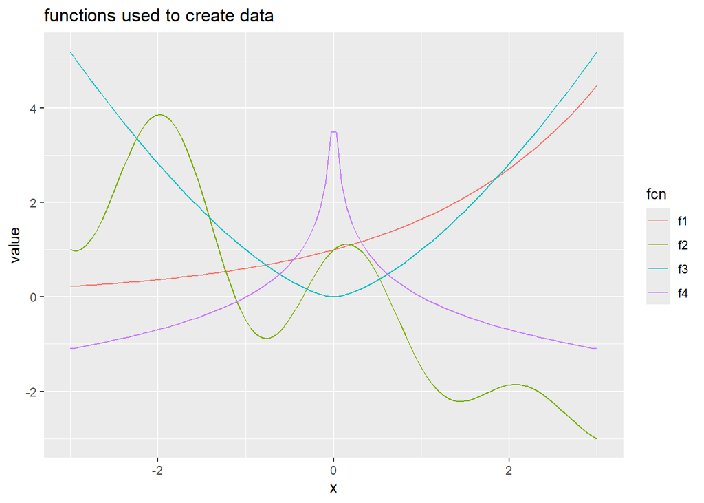

```r
df %>%
  pivot_longer(cols = -x, names_to = "fcn") %>%
  ggplot(aes(y = value, x = x, color = fcn)) +
  geom_line() +
  labs(title = "functions used to create data")
```

```r
# investigating
# as_array(fcn_model$fc1$get_dropout_rates())
# fcn_model$fc1$compute_posterior_param()
# fcn_model$fc1$weight_mu

fcn_model_keeps <- fcn_model$fc1$get_dropout_rates() < 0.05
true_gam <- c(
  rep(T, times = fdat$d_true),
  rep(F, times = fdat$d_in - fdat$d_true)
)
fcn_model_bin_err <- binary_err_rate(est = as_array(fcn_model_keeps), tru =  true_gam)

cat("binary error: \n")
```

```
## binary error:
```

```r
fcn_model_bin_err
```

```
##   FP   TP   FN   TN
## 0.04 1.00 0.00 0.96
```

```r
# post_w1 <- fcn_model$fc1$compute_posterior_param()

# post_w1$post_weight_mu
```

- how to get exact functions? functions from `fcn_model` look good shape-wise, but scale is off.
  - retrain model with only chosen covariates?

```r
lnplot <- function(mu, sig){
  # plots density of log-normal dist'n
  grid <- 1:400 / 100
  dens <- dnorm(log(grid), mean = mu, sd = sig)
  plot(dens ~ grid)
}
```